# Label statistical difference by modifying ggplot objects.

Shuai Yuan

University of Pittsburgh  
yuans@pitt.edu

2026-03-23

```r
library(glue)
library(tidyverse)
library(patchwork)

library(emmeans)

source("ggplot_draw_stat.R")

# Define ggplot theme
theme_yuan <- function(baseFontSize = 8, baseLineWidth = 0.5) {
  font <- "sans"

  theme_classic() %+replace%

    theme(
      panel.grid.major = element_blank(),
      panel.grid.minor = element_blank(),

      axis.title = element_text(
        family = font,
        face = "bold",
        size = baseFontSize
      ),

      axis.text = element_text(
        family = font,
        face = "bold",
        size = baseFontSize * 1
      ),

      legend.title = element_text(
        family = font,
        face = "bold",
        size = baseFontSize
      ),

      legend.text = element_text(
        family = font,
        face = "bold",
        size = baseFontSize * 1
      ),

      axis.line = element_line(color = "black", linewidth = baseLineWidth),
      axis.ticks = element_line(color = "black", linewidth = baseLineWidth),
      axis.ticks.length = unit(baseLineWidth * 2, "mm"),

      strip.background = element_blank(),
      strip.placement = "outside",
      strip.text = element_text(face = "bold", size = baseFontSize)
    )
}
```

# 1 **Introduction**

`draw_stat` adds statistical comparison annotations (bracket + label) to ggplot bar/point/errorbar plots by extracting coordinates from the built ggplot object. Key features:

- Works with single or grouped x-axis variables.
- Supports `facet_wrap` and `facet_grid`, including **multiple facet variables**.
- Input validation with informative error messages.
- Customizable segment and label aesthetics via `draw_stat`.
- `get_annotation_df` is available directly for full control.

# 2 **Simulation Data**

We simulate data with three grouping variables, `Fct1`, `Fct2`, and `Fct3` to mimic a complicated design of biological experiment. The three variables need to be factors.

```r
# Set seed for reproducibility
set.seed(123)
n <- 3

# Fct1 and Fct2 are two independent biological factors
fct1_levels <- LETTERS[1:3]
fct2_levels <- letters[1:3]

# Fct3 is a factor of different measurements to be stratified for statistical analysis and plotting.
fct3_levels <- map_chr(1:4, ~LETTERS[sample(1:26, 4)] %>% str_c(collapse = ""))

df_data <- data.frame(
  Sample = str_c("S", 1:(length(fct1_levels)*length(fct2_levels)*n)) %>%
    rep(times = length(fct3_levels)),
  Fct1 = rep(fct1_levels, each = length(fct2_levels)*n) %>%
    rep(times = length(fct3_levels)) %>%
    factor(levels = fct1_levels),
  Fct2 = rep(fct2_levels, times = length(fct1_levels)*n) %>%
    rep(times = length(fct3_levels)) %>%
    factor(levels = fct2_levels),
  Fct3 = rep(fct3_levels, each = length(fct1_levels)*length(fct2_levels)*n) %>%
    factor(levels = fct3_levels)
)

# Convert factor levels to numeric values
df_data <- df_data %>%
  mutate(
    Fct1_num = as.numeric(Fct1),
    Fct2_num = as.numeric(Fct2),
    Fct3_num = as.numeric(Fct3),
    Fct1_num = Fct1_num - mean(Fct1_num), # Shift the parabola curve to simulate a potential biphasic effect.
    Fct2_num = Fct2_num - mean(Fct2_num)
  )

# Simulate data for each measurement.

# Define the fixed intercept
# The intercept is set positive as most biological measurements are positive.
a0 <- abs(rnorm(length(fct3_levels), 1, 1))

# Define the coefficients for Fct1
b1 <- rnorm(length(fct3_levels), 1)
c1 <- rnorm(length(fct3_levels), 1)

# Define the coefficients for Fct2
b2 <- rnorm(length(fct3_levels), 1)
c2 <- rnorm(length(fct3_levels), 1)

df_data <- df_data %>%
  mutate(
    Value = a0[Fct3_num] + # Intercept
      (b1[Fct3_num]*Fct1_num + c1[Fct3_num]*Fct1_num^2) * # Fct1 effect
      # We allow interaction between Fct1 and Fct2 effects.
      (b2[Fct3_num]*Fct2_num + c2[Fct3_num]*Fct2_num^2) # Fct2 effect
  ) %>%
  group_by(Fct3) %>%
  mutate(
    # Offset simulated values because most biological measurements are positive.
    Value = Value - min(Value),
    # Add error based on mean values so that groups have equal variances.
    Value = Value + rnorm(n(), sd = mean(Value) * 0.2),
    Value = Value - min(Value)
  ) %>%
  select(!contains("_num"))

# Offset simulated values because most biological measurements are positive.
min_value <- min(df_data$Value)

if (min_value < 0) df_data$Value <- df_data$Value - min_value

df_data %>%
  group_by(Fct3) %>%
  slice_head(n=3)
```

```
## # A tibble: 12 × 5
## # Groups:   Fct3 [4]
##    Sample Fct1  Fct2  Fct3  Value
##    <chr>  <fct> <fct> <fct> <dbl>
##  1 S1     A     a     OSNC  1.90
##  2 S2     A     b     OSNC  1.09
##  3 S3     A     c     OSNC  0.713
##  4 S1     A     a     JRVK  6.07
##  5 S2     A     b     JRVK  0.967
##  6 S3     A     c     JRVK  3.47
##  7 S1     A     a     ETNV  7.95
##  8 S2     A     b     ETNV  6.49
##  9 S3     A     c     ETNV  0
## 10 S1     A     a     YESI  0.697
## 11 S2     A     b     YESI  0.647
## 12 S3     A     c     YESI  0.146
```

# 3 **Statistical Tests**

The data is simulated to have differences between groups. Here we use ANOVA and Tukey’s post-hoc tests to find out the differences. The result is saved in a dataframe with columns `Group1`, `Group2`, and `Label`.

`Group1` and `Group2` must match the values produced by `interaction(contrast_vars, sep = sep)` — i.e., the same labels that would result from pasting the contrast variable values together.

`main_geom_idx` is the index of the geom/stat layer used to retrieve the `x` positions of each group.

```r
# Statistical tests
df_stat <- df_data %>%
  group_by(Fct3) %>%
  nest() %>%
  mutate(
    m = map(data, ~aov(Value~Fct1*Fct2, data = .x)),
    m.pvalue = map(m, function(x){
      x <- summary(x)
      pvalues <- x[[1]]$`Pr(>F)`
      data.frame(
        Fct1.pvalue = pvalues[1],
        Fct2.pvalue = pvalues[2],
        Fct1.Fct2.pvalue = pvalues[3]
      )
    })
  ) %>%
  unnest(m.pvalue) %>%
  filter(
    any(across(contains(".pvalue"), ~.x<0.05)) # We only keep a model if there is any significance.
  ) %>%
  mutate(
    post.hoc.pvalue = map(m, function(x){
      emm <- emmeans(x, ~Fct1*Fct2)
      df_pvalues <- summary(contrast(emm, "pairwise", adjust = "tukey")) %>%
        select(contrast, p.value) # We only care about contrast and p-values.
    })
  ) %>%
  select(Fct3, post.hoc.pvalue) %>% # We can remove unwanted data before unnesting to save memory.
  unnest(post.hoc.pvalue) %>%
  filter(p.value < 0.05) %>% # We only keep significant comparisons.
  ungroup()

df_stat <- df_stat %>%
  mutate(
    Group1 = map_chr(contrast, ~str_split_1(.x, " - ") %>% first()),
    Group2 = map_chr(contrast, ~str_split_1(.x, " - ") %>% last()),
    Label = ifelse(p.value<0.05, "*", "")
  ) %>%
  # filter(Fct3 == levels(Fct3)[1]) %>%
  filter(map2_vec(Group1, Group2, ~length(intersect(str_split_1(.x, " "), str_split_1(.y, " "))) > 0))

 df_stat %>%
  group_by(Fct3) %>%
  slice_head(n=3)
```

```
## # A tibble: 12 × 6
## # Groups:   Fct3 [4]
##    Fct3  contrast   p.value Group1 Group2 Label
##    <fct> <chr>        <dbl> <chr>  <chr>  <chr>
##  1 OSNC  A a - B a 3.40e- 5 A a    B a    *
##  2 OSNC  A a - C a 2.13e- 9 A a    C a    *
##  3 OSNC  A a - A b 5.11e- 5 A a    A b    *
##  4 JRVK  A a - B a 2.55e-14 A a    B a    *
##  5 JRVK  A a - C a 2.53e-14 A a    C a    *
##  6 JRVK  A a - A b 2.60e-14 A a    A b    *
##  7 ETNV  A a - C a 1.87e- 2 A a    C a    *
##  8 ETNV  A a - A c 1.54e- 5 A a    A c    *
##  9 ETNV  C a - C c 1.22e- 5 C a    C c    *
## 10 YESI  A a - C a 1.42e- 4 A a    C a    *
## 11 YESI  A a - A c 4.11e- 6 A a    A c    *
## 12 YESI  B a - C a 1.11e- 2 B a    C a    *
```

# 4 **Plots**

## 4.1 Single panel, x = group

In a simple experiment, we may only have one grouping variable, such as `Treatment` with different levels. For such experimental designs, we can simply use `x = Treatment`. Let’s pretend the interaction of Fct1 and Fct2 is the treatment variable.

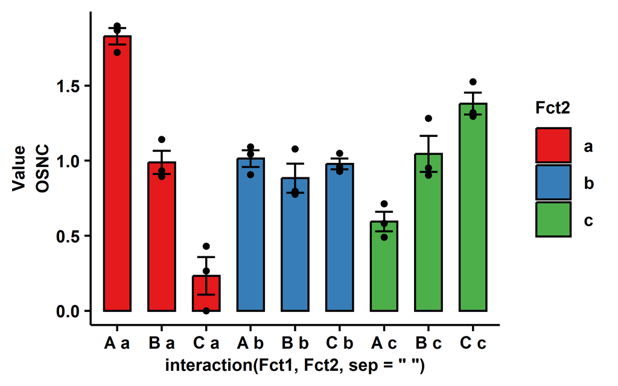

```r
p <- df_data %>%
  filter(Fct3 == levels(Fct3)[1]) %>%
  ggplot(aes(x = interaction(Fct1, Fct2, sep = " "), y = Value)) +
  stat_summary(geom = "col", fun = "mean", aes(fill = Fct2), color = "black", position = position_dodge(width = 0.8), width = 0.6) +
  stat_summary(geom = "errorbar", fun.data = "mean_se", aes(group = Fct2), position = position_dodge(width = 0.8), width = 0.4) +
  geom_point(aes(group = Fct2), size = 1, position = position_dodge(0.8)) +
  scale_fill_brewer(palette = "Set1") +
  facet_wrap(~Fct3, scale = "free", strip.position = "left") +
  theme_yuan()

p
```

To draw the statistics, we simply modify the ggplot object `p` with `draw_stat`. Instead of adding a special aesthetic, we pass `contrast_vars = c("Fct1", "Fct2")` - the column names whose interaction produces the `Group1`/`Group2` labels in `df_stat`. The function resolves x-positions internally from the built plot data.

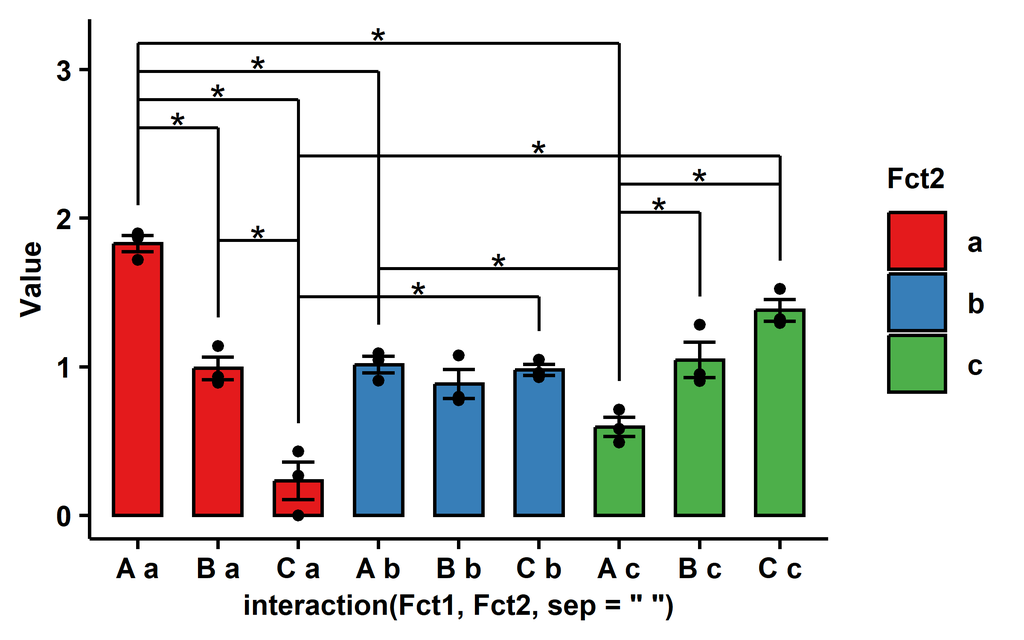

```r
p <- df_data %>%
  filter(Fct3 == levels(Fct3)[1]) %>%
  ggplot(aes(x = interaction(Fct1, Fct2, sep = " "), y = Value)) +
  stat_summary(geom = "col", fun = "mean", aes(fill = Fct2), color = "black", position = position_dodge(width = 0.8), width = 0.6) +
  stat_summary(geom = "errorbar", fun.data = "mean_se", aes(group = Fct2), position = position_dodge(width = 0.8), width = 0.4) +
  geom_point(aes(group = Fct2), size = 1, position = position_dodge(0.8)) +
  scale_fill_brewer(palette = "Set1") +
  theme_yuan()

draw_stat(p, df_stat %>% filter(Fct3 == levels(Fct3)[1]), contrast_vars = c("Fct1", "Fct2"), ypad_ratio = 0.1)
```

Note that the coordinates for segments and labels are calculated based on a main geom or stat layer declared by `main_geom_idx`, which contains the exact x position of an individual group. If there are a range of x values for data in the same group (e.g., jittered points), the user had to specify the appropriate layer index in previous versions of the function. This no longer seems to be necessary with explicitly declaring `contrast_vars`. `main_geom_idx` may be removed in future updates.

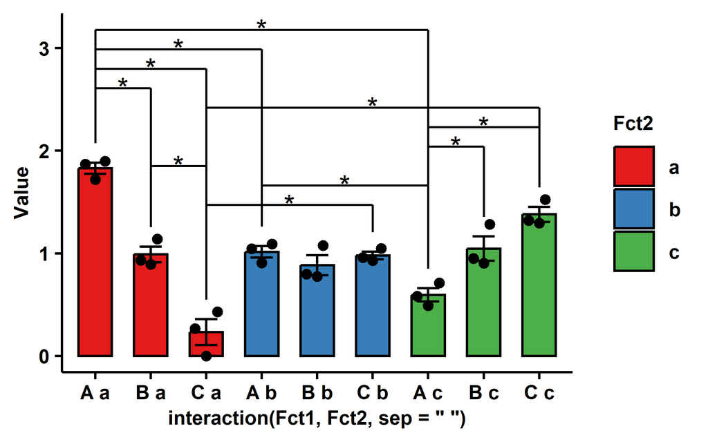

```r
p <- df_data %>%
  filter(Fct3 == levels(Fct3)[1]) %>%
  ggplot(aes(x = interaction(Fct1, Fct2, sep = " "), y = Value)) +
  stat_summary(geom = "col", fun = "mean", aes(fill = Fct2), color = "black", position = position_dodge(width = 0.8), width = 0.6) +
  stat_summary(geom = "errorbar", fun.data = "mean_se", aes(group = Fct2), position = position_dodge(width = 0.8), width = 0.4) +
  # geom_point(aes(group = Fct2), size = 1, position = position_dodge(0.8)) +
  ggbeeswarm::geom_quasirandom() +
  scale_fill_brewer(palette = "Set1") +
  theme_yuan()

draw_stat(p, df_stat %>% filter(Fct3 == levels(Fct3)[1]), contrast_vars = c("Fct1", "Fct2"), ypad_ratio = 0.1, main_geom_idx = 3)
```

## 4.2 Single panel, x = Fct1, group = Fct2

In a more complicated experimental design, we may have two variables such as `Treatment` and `Genotype`, each with multiple levels. Let’s pretend `Fct1` is `Treatment`, and `Fct2` is `Genotype`.

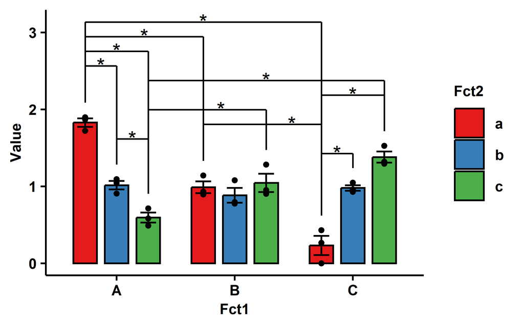

```r
p <- df_data %>%
  filter(Fct3 == levels(Fct3)[1]) %>%
  ggplot(aes(x = Fct1, y = Value)) +
  stat_summary(geom = "col", fun = "mean", aes(fill = Fct2), color = "black", position = position_dodge(width = 0.8), width = 0.6) +
  stat_summary(geom = "errorbar", fun.data = "mean_se", aes(group = Fct2), position = position_dodge(width = 0.8), width = 0.4) +
  geom_point(aes(group = Fct2), size = 1, position = position_dodge(0.8)) +
  scale_fill_brewer(palette = "Set1") +
  theme_yuan()


draw_stat(p, df_stat %>% filter(Fct3 == levels(Fct3)[1]), contrast_vars = c("Fct1", "Fct2"), ypad_ratio = 0.1)
```

## 4.3 Multiple panels, x = group

Now let’s add multiple panels. Here, we use Fct3 as the facet variable. Think of it as measuring different mRNA expression with the same experimental groups.

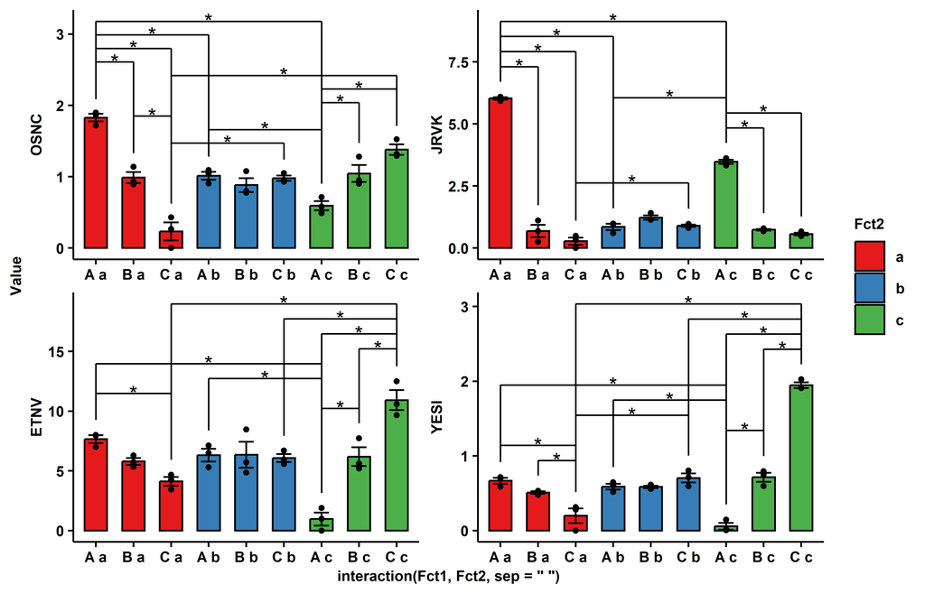

```r
p <- df_data %>%
  ggplot(aes(x = interaction(Fct1, Fct2, sep = " "), y = Value)) +
  stat_summary(geom = "col", fun = "mean", aes(fill = Fct2), color = "black", position = position_dodge(width = 0.8), width = 0.6) +
  stat_summary(geom = "errorbar", fun.data = "mean_se", aes(group = Fct2), position = position_dodge(width = 0.8), width = 0.4) +
  geom_point(aes(group = Fct2), size = 1, position = position_dodge(0.8)) +
  scale_fill_brewer(palette = "Set1") +
  facet_wrap(~Fct3, scale = "free", strip.position = "left") +
  theme_yuan()

draw_stat(p, df_stat, contrast_vars = c("Fct1", "Fct2"), ypad_ratio = 0.1)
```

## 4.4 Multiple panels, x = Fct1, group = Fct2

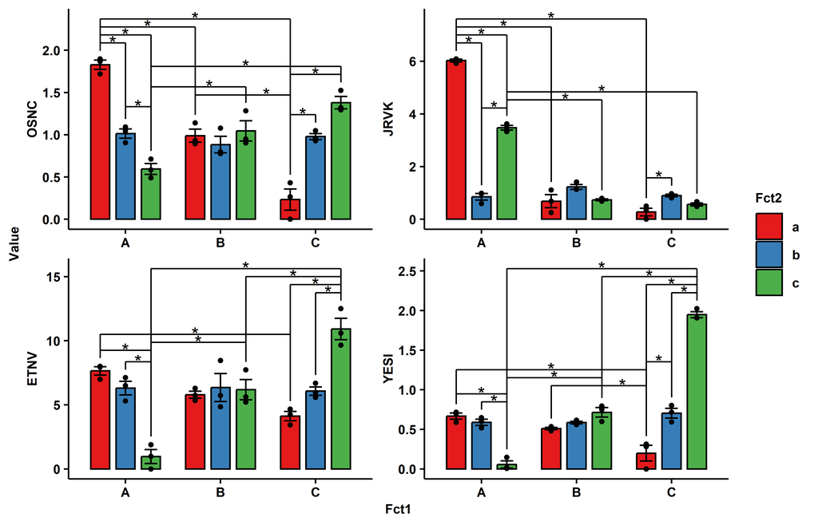

```r
p <- df_data %>%
  ggplot(aes(x = Fct1, y = Value)) +
  stat_summary(geom = "col", fun = "mean", aes(fill = Fct2), color = "black", position = position_dodge(width = 0.8), width = 0.6) +
  stat_summary(geom = "errorbar", fun.data = "mean_se", aes(group = Fct2), position = position_dodge(width = 0.8), width = 0.4) +
  geom_point(aes(group = Fct2), size = 1, position = position_dodge(0.8)) +
  scale_fill_brewer(palette = "Set1") +
  facet_wrap(~Fct3, scale = "free", strip.position = "left") +
  theme_yuan()

draw_stat(p, df_stat, contrast_vars = c("Fct1", "Fct2"))
```

## 4.5 Multiple facet variables with `facet_wrap`

Multiple facet variables are now supported. When using multiple facet variables, `contrast_df` must contain columns matching all facet variable names. The function creates a composite panel identifier internally to match annotations to the correct panels.

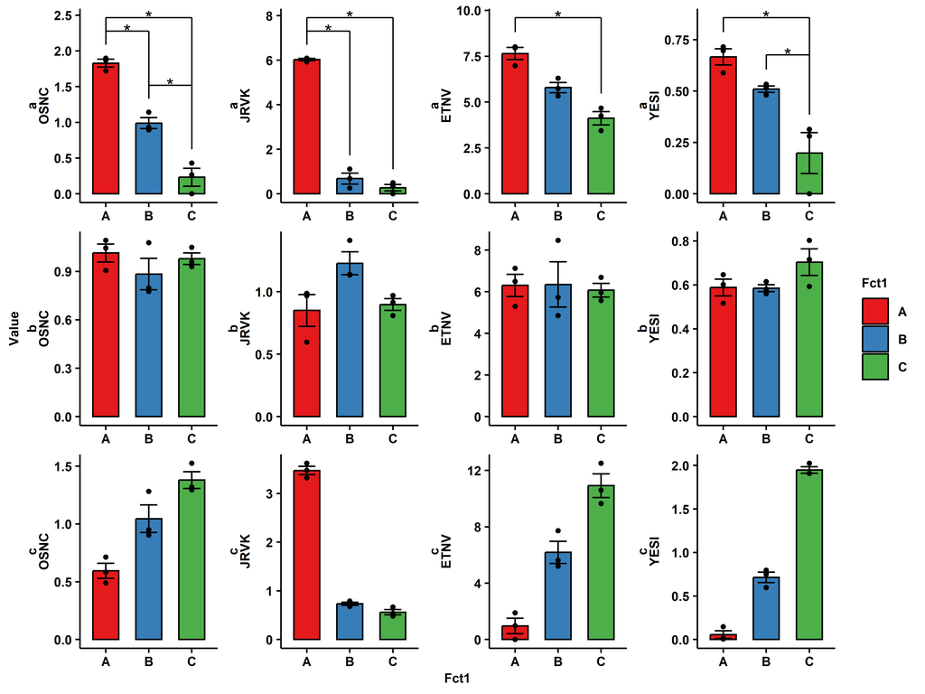

```r
# For multi-facet, we need both Fct2 and Fct3 columns in contrast_df.
# df_stat already has Fct3. We need to add Fct2.
# Since our contrast groups encode Fct2 in "Group1"/"Group2", we extract it.
df_stat_multi <- df_stat %>%
  mutate(
    # Extract Fct2 from Group1 (the second token, e.g., "A a" -> "a")
    Fct2_g1 = map_chr(Group1, ~str_split_1(.x, " ")[2]),
    Fct2_g2 = map_chr(Group2, ~str_split_1(.x, " ")[2])
  ) %>%
  # Keep only comparisons within the same Fct2 level for this demo
  filter(Fct2_g1 == Fct2_g2) %>%
  mutate(Fct2 = factor(Fct2_g1, levels = levels(df_data$Fct2))) %>%
  select(-Fct2_g1, -Fct2_g2)

p <- df_data %>%
  ggplot(aes(x = Fct1, y = Value)) +
  stat_summary(geom = "col", aes(fill = Fct1), fun = "mean", color = "black", position = position_dodge(width = 0.8), width = 0.6) +
  stat_summary(geom = "errorbar", fun.data = "mean_se", position = position_dodge(width = 0.8), width = 0.4) +
  geom_point(size = 1, position = position_dodge(0.8)) +
  scale_fill_brewer(palette = "Set1") +
  facet_wrap(~Fct2 + Fct3, scale = "free", strip.position = "left") +
  theme_yuan()

draw_stat(p, df_stat_multi, contrast_vars = c("Fct1", "Fct2"), ypad_ratio = 0.1)
```

## 4.6 Multiple facet variables with `facet_grid`

The function also supports `facet_grid`. The same requirement applies: `contrast_df` must have columns matching the facet variables.

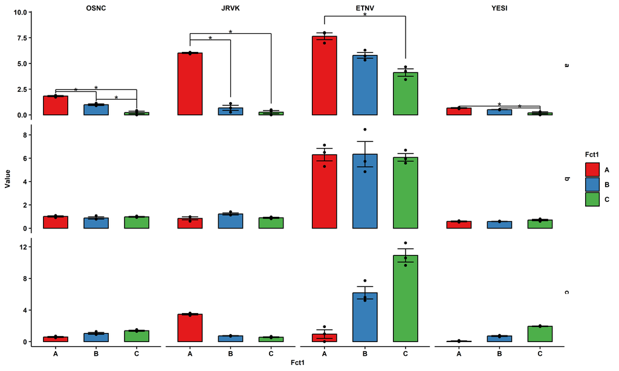

```r
p <- df_data %>%
  ggplot(aes(x = Fct1, y = Value)) +
  stat_summary(geom = "col", aes(fill = Fct1), fun = "mean", color = "black", position = position_dodge(width = 0.8), width = 0.6) +
  stat_summary(geom = "errorbar", fun.data = "mean_se", position = position_dodge(width = 0.8), width = 0.4) +
  geom_point(size = 1, position = position_dodge(0.8)) +
  scale_fill_brewer(palette = "Set1") +
  facet_grid(Fct2 ~ Fct3, scales = "free_y") +
  theme_yuan()

draw_stat(p, df_stat_multi, contrast_vars = c("Fct1", "Fct2"), ypad_ratio = 0.1)
```

## 4.7 Customizing annotation appearance

`draw_stat` exposes `segment_linewidth`, `label_size`, and `label_color` for quick styling without needing to call `get_annotation_df` directly.

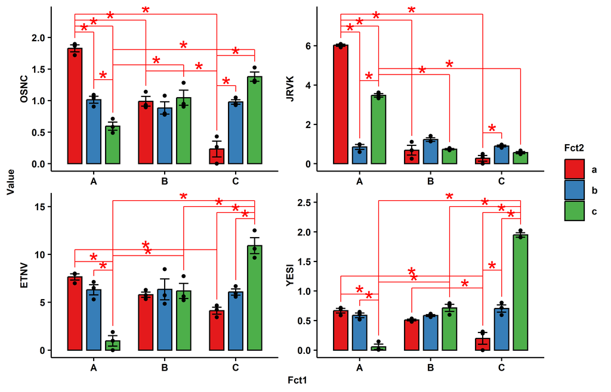

```r
p <- df_data %>%
  ggplot(aes(x = Fct1, y = Value)) +
  stat_summary(geom = "col", fun = "mean", aes(fill = Fct2), color = "black", position = position_dodge(width = 0.8), width = 0.6) +
  stat_summary(geom = "errorbar", fun.data = "mean_se", aes(group = Fct2), position = position_dodge(width = 0.8), width = 0.4) +
  geom_point(aes(group = Fct2), size = 1, position = position_dodge(0.8)) +
  scale_fill_brewer(palette = "Set1") +
  facet_wrap(~Fct3, scale = "free", strip.position = "left") +
  theme_yuan()

draw_stat(p, df_stat, contrast_vars = c("Fct1", "Fct2"),
          segment_linewidth = 0.3, label_size = 20, label_color = "red")
```

# 5 **Additional Notes**

`draw_stat` is a wrapper function calling `get_annotation_df` to calculate annotation coordinates. The user can call this function directly for more flexibility.

```r
p <- df_data %>%
  ggplot(aes(x = Fct1, y = Value)) +
  stat_summary(geom = "col", fun = "mean", aes(fill = Fct2), color = "black", position = position_dodge(width = 0.8), width = 0.6) +
  stat_summary(geom = "errorbar", fun.data = "mean_se", aes(group = Fct2), position = position_dodge(width = 0.8), width = 0.4) +
  geom_point(aes(group = Fct2), size = 1, position = position_dodge(0.8)) +
  scale_fill_brewer(palette = "Set1") +
  facet_wrap(~Fct3, scale = "free", strip.position = "left") +
  theme_yuan()

df_annot_tbl <- get_annotation_df(p, df_stat, contrast_vars = c("Fct1", "Fct2"), ypad_ratio = 0.5)
head(df_annot_tbl)
```

```
## # A tibble: 6 × 19
##   Fct3  contrast    p.value Group1 Group2 Label panel_name Group1.x Group2.x
##   <fct> <chr>         <dbl> <chr>  <chr>  <chr> <chr>         <dbl>    <dbl>
## 1 ETNV  A b - A c 0.000276  A b    A c    *     ETNV          1         1.27
## 2 ETNV  A a - A c 0.0000154 A a    A c    *     ETNV          0.733     1.27
## 3 ETNV  A c - B c 0.000364  A c    B c    *     ETNV          1.27      2.27
## 4 ETNV  A a - C a 0.0187    A a    C a    *     ETNV          0.733     2.73
## 5 ETNV  C b - C c 0.000866  C b    C c    *     ETNV          3         3.27
## 6 ETNV  C a - C c 0.0000122 C a    C c    *     ETNV          2.73      3.27
## # ℹ 10 more variables: Group1.y <dbl>, Group2.y <dbl>, ymax <dbl>, mid.x <dbl>,
## #   overlapping_group <dbl>, ypad <dbl>, ymax_adj <dbl>, Group1.y_adj <dbl>,
## #   Group2.y_adj <dbl>, mid.x_adj <dbl>
```

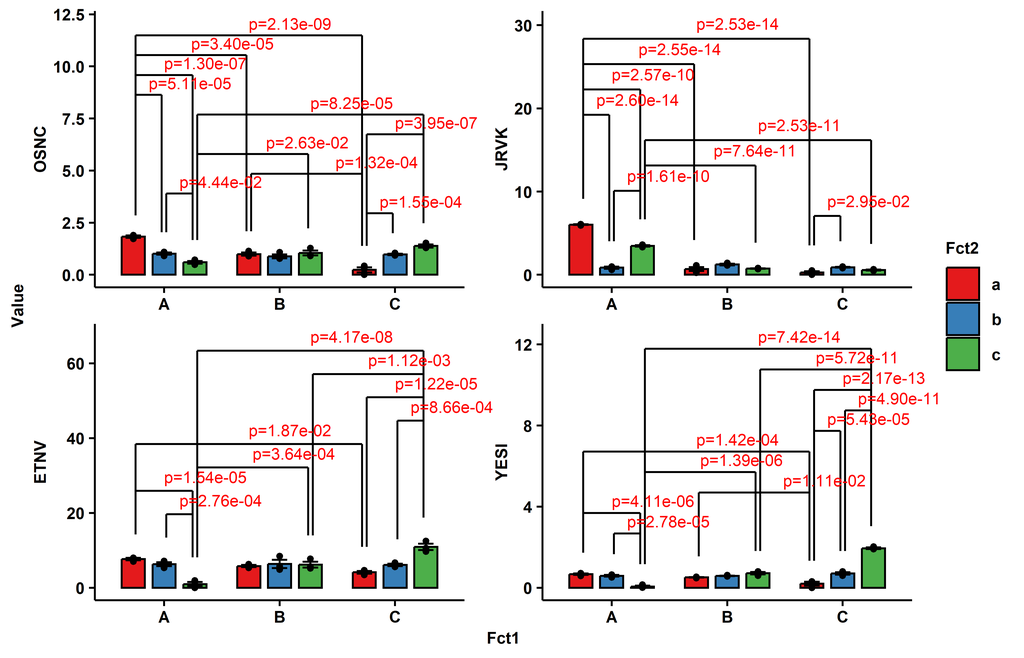

```r
segment_x_pad <- 0.02
p +
  geom_segment(data = df_annot_tbl, aes(x = Group1.x+segment_x_pad, y = ymax_adj, xend = Group2.x-segment_x_pad, yend = ymax_adj), linewidth = 0.5, inherit.aes = FALSE) +
  geom_segment(data = df_annot_tbl, aes(x = Group1.x+segment_x_pad, y = Group1.y_adj, xend = Group1.x+segment_x_pad, yend = ymax_adj), linewidth = 0.5, inherit.aes = FALSE) +
  geom_segment(data = df_annot_tbl, aes(x = Group2.x-segment_x_pad, y = Group2.y_adj, xend = Group2.x-segment_x_pad, yend = ymax_adj), linewidth = 0.5, inherit.aes = FALSE)+
  geom_text(data = df_annot_tbl, aes(x = mid.x_adj, y = ymax_adj+ypad*0.6, label = glue("p={formatC(p.value, digits = 2, format = 'e')}")), size = 8, hjust = 0, size.unit = "pt", color = "red",  inherit.aes = FALSE) +
  coord_cartesian(clip = "off") +
  theme(
    panel.spacing.x = unit(5, "mm")
  )
```

# 6 **Known Limitations**

- **Many overlapping comparisons**: With a large number of significant pairwise comparisons, annotations can stack high above the data. Consider filtering `contrast_df` to the most relevant comparisons.
- **`scales = "free_x"` with facets**: If x-axis scales differ across panels, the shared x-coordinate lookup may produce incorrect results. This is uncommon for typical grouped bar plots.